# IODS course project

Pingxin Gao

# About the project

After learning online course from the Data Camp, I think all the programming languages are essentially the same. R is very similar to Python, and some functions are just like one the the Python library (Pandas), since they all use Dataframe object to store information, so I find it very easy to understand, and I think R is focused on the data processing where as Python is more of general purpose type of language.

My github repository is [here](https://github.com/gpx135/IODS-project).

My course diary web page is [here](https://gpx135.github.io/IODS-project/).

# R basics

- assign a value:

```r
something <- value
```

- add comment

```r
# some_comment (just like python)
```

- execute a line of code (just like debug mode but not entirely the same)

```r
Cmd/ctrl + Enter
```

- basic arithmetics

```r
+ # Addition
- # Subtraction
* # Multiplication
/ # Division
^ (or **) # Exponentiation
```

- excecute a function

```r
some_function(object)
```

- take mean value

```r
mean(data_source)
```

- access first a lines of dataframe

```r
head(students2014, n = a)
# its a good practice to add the argument name to avoid confusion
```

- structure of data

```r
str(data_source)
# but in python it prints out string of an object
```

- data types: numeric, characters, logical, factor(new concept conpared to python)

```r
"Strongly disagree" = 1
"Strongly agree" = 5
```

```r
# Boolean values: TRUE or FALSE
# all upper case
```

- create a vactor

```r
c(2, 3, 4.1, 5) # has to be same data type
```

- summary of the data

```r
summary(data source)
# it will return some important statistical value of the selected data
```

- plot a scatter figure

```r
plot(x, y, "p", main = "some title")
```

- manupulate a value of a vector

```r
names[1]
# start at 1 not 0
names[1] <- "new_value"
names[c(1, 3)] # select value from these positions, order matters
```

- create a integer vector

```r
c[1, 2, 3, 4, 5]
1:5

# manupulate the vector
(1:5)*2

# length of the data
length(data)

slicing
data[begin:end]
# possible to modify the vector when slicing a dataframe
```

- logical comparison

```r
==  # exactly equal to
!=  # not equal to
<   # less than
>   # greater than
<=  # less or equal to
>=  # greater or equal to
!a  # NOT a
a & b   # a AND b
a | b   # a OR b
```

- take sebset of the dataframe

```r
subset(data_source, conditions...)
```

- looping

```r
for (counter in vector) {
  commands
  more commands
}
```

- access a library
- create functions

```r
function_name <- function(arg1, arg2 = 5) return(return_value) # arg = default value
```

```r
varible <- read.table("source_of data", sep="\t", header=TRUE) # read data
dim(data) # check dimension
str(data) # check structure
colSums(df) # returns a sum of each column in df
rowSums(df) # returns a sum of each row in df
colMeans(df)    # returns the mean of each column in df
rowMeans(df) # return the mean of each row in df
select(dataframe, one_of(columes)) # select columns to create new datafram
colnames(data)[columm_index] <- "new_name" # modify column names
filtered_data <- filter(original_data, conditions) # filter the data with conditions

# If-else statement
if(condition) {
   do something
} else {
   do something else
}

c(1,2,3,4,5) / 2 # scaling vectors

%>% # pipe operator


select(data_source, one_of(vector_of_columns)) # select few columns as new one

colnames(data) # print colunm names

data_frame <- as.data.frame(scaled) # change data to data frame

sample() # choose ramdom data

mutate() # adding new variables as mutations of the existing ones

jointed_data <- inner_join(first_data, second_data, by = common_columns, suffix = c(".first", ".second"))
```

# 2. Learning Questionnaire Analysis

## 2.1 Introduction

The original data has 60 variables and 183 observations; most of the questions were given on Likert scale, from 1 to 5, except for the few background related variables (age, attitude, points). For the analysis part, the variables related to deep learning, surface learning, and strategic learning have been scaled using [R script](https://github.com/gpx135/IODS-project/blob/master/data/create_learning2014.R).

## 2.2 Data overview

```r
# Read in the data
new_lrn14 <- as.data.frame(read.csv('data/learning2014.csv'))
```

A matrix of plots of variables of the data can be drawn as follows, coloured according to gender variable:

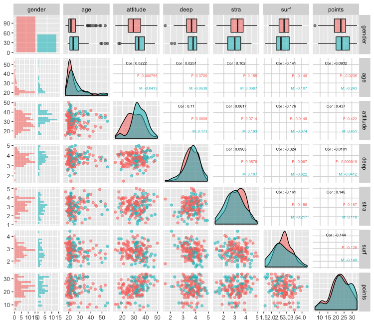

```r
p <- ggpairs(new_lrn14, mapping = aes(col = gender), lower = list(combo = wrap("facethist", bins = 20)))
p
```

```r
summary(new_lrn14)
```

Results:

```
gender       age           attitude          deep            stra            surf           points
 F:110   Min.   :17.00   Min.   :14.00   Min.   :1.583   Min.   :1.250   Min.   :1.583   Min.   : 7.00
 M: 56   1st Qu.:21.00   1st Qu.:26.00   1st Qu.:3.333   1st Qu.:2.625   1st Qu.:2.417   1st Qu.:19.00
         Median :22.00   Median :32.00   Median :3.667   Median :3.188   Median :2.833   Median :23.00
         Mean   :25.51   Mean   :31.43   Mean   :3.680   Mean   :3.121   Mean   :2.787   Mean   :22.72
         3rd Qu.:27.00   3rd Qu.:37.00   3rd Qu.:4.083   3rd Qu.:3.625   3rd Qu.:3.167   3rd Qu.:27.75
         Max.   :55.00   Max.   :50.00   Max.   :4.917   Max.   :5.000   Max.   :4.333   Max.   :33.00
```

The gender variable inllustrate that this course was attended by more female students. Most of the variables are distributed randomly and shows weak correlation with the points. The correlation between points and attitude is the largest between all the variables. Most of the variables seems to be close to normal distribution except gender and age.

## 2.3 Fitting a Regression Model

```r
lrn2014_model <- lm(points ~ attitude + stra + surf, data = new_lrn14)
summary(lrn2014_model)
```

```
Call:
lm(formula = points ~ attitude + stra + surf, data = new_lrn14)

Residuals:
     Min       1Q   Median       3Q      Max
-17.1550  -3.4346   0.5156   3.6401  10.8952

Coefficients:
            Estimate Std. Error t value Pr(>|t|)
(Intercept) 11.01711    3.68375   2.991  0.00322 **
attitude     0.33952    0.05741   5.913 1.93e-08 ***
stra         0.85313    0.54159   1.575  0.11716
surf        -0.58607    0.80138  -0.731  0.46563
---
Signif. codes:  0 ‘***’ 0.001 ‘**’ 0.01 ‘*’ 0.05 ‘.’ 0.1 ‘ ’ 1

Residual standard error: 5.296 on 162 degrees of freedom
Multiple R-squared:  0.2074,    Adjusted R-squared:  0.1927
F-statistic: 14.13 on 3 and 162 DF,  p-value: 3.156e-08
```

```r
lrn2014_model <- lm(points ~ attitude + stra, data = new_lrn14)
summary(lrn2014_model)
```

[output not shown]

## 2.5 Diagnostic Plots and Assumptions

For a linear model, there are following assumptions:

1. The errors are not correlated.
2. The size of the errors does not depend on the explanatory variables.
3. The errors of the model should be normally distributed.

The validity of these assumption can be tested by analysing the residuals of the model. In the following figure three different diagnostic plots are drawn:

- Residuals vs. fitted values plot
- Normal Q–Q plot
- Residuals vs. leverage plot

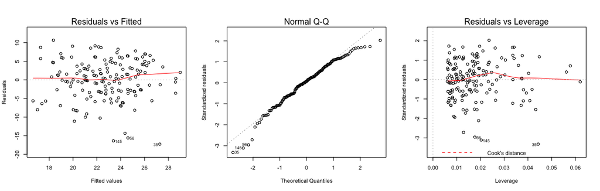

```r
par(mfrow = c(1,3))
plot(new_lrn14_model, which = c(1,2,5))
```

Interpretations:

1. From the first plot, the residuals vs. fitted values plot doesn’t show any kind of pattern or correlation, so the errors are not correlated and their size is independent of the explanatory variables.
2. The Q–Q-plot shows reasonably well fit between the standardised residuals and theoretical quantities, thus confirms the validity of normal distribution assumption.
3. From the thid plor, we can conclude that the model is not distorted by any single observation since the x-axis scale of the residuals vs. leverage plot is relatively narrow and no significant outliers was observed.

# 3. Alcohol Consumption Analysis

## 3.1 Introduction

## 3.2 Overview of the Data

```r
alc <- as.data.frame(read.table('data/alc.csv',  sep="\t", header=TRUE))
glimpse(alc)
```

Results:

```
Observations: 382
Variables: 35
$ school     <fct> GP, GP, GP, GP, GP, GP, GP, GP, GP, GP, GP, GP, GP, GP, GP, GP, GP, GP, GP, GP, GP, GP, G…
$ sex        <fct> F, F, F, F, F, M, M, F, M, M, F, F, M, M, M, F, F, F, M, M, M, M, M, M, F, F, M, M, M, M,…
$ age        <int> 18, 17, 15, 15, 16, 16, 16, 17, 15, 15, 15, 15, 15, 15, 15, 16, 16, 16, 17, 16, 15, 15, 1…
$ address    <fct> U, U, U, U, U, U, U, U, U, U, U, U, U, U, U, U, U, U, U, U, U, U, U, U, R, U, U, U, U, U,…
$ famsize    <fct> GT3, GT3, LE3, GT3, GT3, LE3, LE3, GT3, LE3, GT3, GT3, GT3, LE3, GT3, GT3, GT3, GT3, GT3,…
$ Pstatus    <fct> A, T, T, T, T, T, T, A, A, T, T, T, T, T, A, T, T, T, T, T, T, T, T, T, T, T, T, T, A, T,…
$ Medu       <int> 4, 1, 1, 4, 3, 4, 2, 4, 3, 3, 4, 2, 4, 4, 2, 4, 4, 3, 3, 4, 4, 4, 4, 2, 2, 2, 2, 4, 3, 4,…
$ Fedu       <int> 4, 1, 1, 2, 3, 3, 2, 4, 2, 4, 4, 1, 4, 3, 2, 4, 4, 3, 2, 3, 3, 4, 2, 2, 4, 2, 2, 2, 4, 4,…
$ Mjob       <fct> at_home, at_home, at_home, health, other, services, other, other, services, other, teache…
$ Fjob       <fct> teacher, other, other, services, other, other, other, teacher, other, other, health, othe…
$ reason     <fct> course, course, other, home, home, reputation, home, home, home, home, reputation, reputa…
$ nursery    <fct> yes, no, yes, yes, yes, yes, yes, yes, yes, yes, yes, yes, yes, yes, yes, yes, yes, yes, …
$ internet   <fct> no, yes, yes, yes, no, yes, yes, no, yes, yes, yes, yes, yes, yes, yes, yes, yes, no, yes…
```

[output cut: 22 more lines]

## 3.3 Purpose of the Analysis

I’ve chosen the following 4 variables that I assume are indicative of students’ alcohol consumption:

- Final grade (variable G3). My assumption is that who got lower grade drink more.
- Failures (variable failures). My assumption is that who fails more drink more.
- Absence of lessons (variable absences). My assumption is that who skip lessons drink more.
- Study time (variable studytime). My assumption is that who spend less time studying spend more time drinking.

A summary and plots of the chosen variables are shown below. Also, grouped the box plots by sex to see possible correlation.

```r
summary(alc[c('G3','failures','absences','studytime')])
```

```
       G3           failures         absences      studytime
 Min.   : 0.00   Min.   :0.0000   Min.   : 0.0   Min.   :1.000
 1st Qu.:10.00   1st Qu.:0.0000   1st Qu.: 1.0   1st Qu.:1.000
 Median :12.00   Median :0.0000   Median : 3.0   Median :2.000
 Mean   :11.46   Mean   :0.2016   Mean   : 4.5   Mean   :2.037
 3rd Qu.:14.00   3rd Qu.:0.0000   3rd Qu.: 6.0   3rd Qu.:2.000
 Max.   :18.00   Max.   :3.0000   Max.   :45.0   Max.   :4.000
```

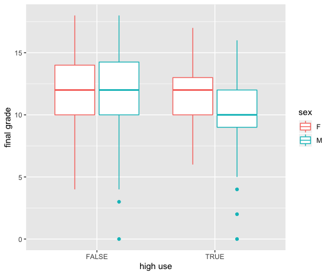

[figure not shown]

[figure not shown]

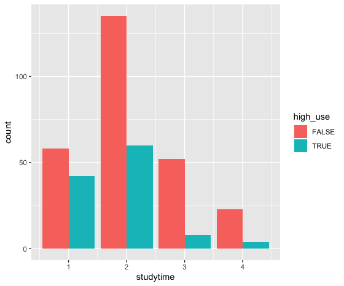

```r
# plot

p1 <- ggplot(alc, aes(x = high_use, y = G3, col=sex)) + geom_boxplot() + xlab('high use')
p2 <- ggplot(alc, aes(failures)) + geom_bar(aes(fill = high_use), position = "dodge", stat="count") + xlab('going out')
p3 <- ggplot(alc, aes(x = high_use, y = absences, col=sex)) + geom_boxplot() + ylab('final grade') + xlab('high use')
p4 <- ggplot(alc, aes(studytime)) + geom_bar(aes(fill = high_use), position = "dodge", stat="count")
```

## 3.4 Logistic Regression Analysis

```r
m <- glm(high_use ~ G3 + failures + absences + studytime, data = alc, family = "binomial")
summary(m)
```

```
Call:
glm(formula = high_use ~ G3 + failures + absences + studytime,
    family = "binomial", data = alc)

Deviance Residuals:
    Min       1Q   Median       3Q      Max
-2.1570  -0.8393  -0.6605   1.1103   2.1227

Coefficients:
            Estimate Std. Error z value Pr(>|z|)
(Intercept)  0.02933    0.56149   0.052 0.958346
G3          -0.03519    0.03868  -0.910 0.362964
failures     0.29443    0.20422   1.442 0.149383
absences     0.07766    0.02271   3.420 0.000626 ***
studytime   -0.47423    0.15920  -2.979 0.002893 **
---
Signif. codes:  0 ‘***’ 0.001 ‘**’ 0.01 ‘*’ 0.05 ‘.’ 0.1 ‘ ’ 1

(Dispersion parameter for binomial family taken to be 1)

    Null deviance: 465.68  on 381  degrees of freedom
Residual deviance: 429.15  on 377  degrees of freedom
AIC: 439.15

Number of Fisher Scoring iterations: 4
```

According to the model summary, my hypothesis was wrong with regard the final grade and failure. The other two explanatory variables are relatively strong predictors. Odds ratios were calculated:

```r
or <- exp(coef(m))
or
```

```
(Intercept)          G3    failures    absences   studytime
  1.0297605   0.9654265   1.3423577   1.0807536   0.6223632
```

Confidence intervals:

```r
ci <- exp(confint(m))
cbind(or, ci)
```

```
                   or     2.5 %    97.5 %
(Intercept) 1.0297605 0.3412502 3.1040114
G3          0.9654265 0.8948227 1.0417846
failures    1.3423577 0.9000830 2.0158575
absences    1.0807536 1.0359926 1.1326415
studytime   0.6223632 0.4513693 0.8437505
```

```r
m <- glm(high_use ~ failures + absences + studytime, data = alc, family = "binomial")
summary(m)
```

```
Call:
glm(formula = high_use ~ failures + absences + studytime, family = "binomial",
    data = alc)

Deviance Residuals:
    Min       1Q   Median       3Q      Max
-2.1536  -0.8385  -0.6825   1.1469   2.1604

Coefficients:
            Estimate Std. Error z value Pr(>|z|)
(Intercept) -0.36590    0.35603  -1.028 0.304080
failures     0.36378    0.19023   1.912 0.055845 .
absences     0.07897    0.02271   3.477 0.000507 ***
studytime   -0.48619    0.15855  -3.066 0.002166 **
---
Signif. codes:  0 ‘***’ 0.001 ‘**’ 0.01 ‘*’ 0.05 ‘.’ 0.1 ‘ ’ 1

(Dispersion parameter for binomial family taken to be 1)

    Null deviance: 465.68  on 381  degrees of freedom
Residual deviance: 429.97  on 378  degrees of freedom
AIC: 437.97

Number of Fisher Scoring iterations: 4
```

```r
cbind(exp(coef(m)), exp(confint(m)))
```

```
                          2.5 %    97.5 %
(Intercept) 0.6935745 0.3442726 1.3944631
failures    1.4387512 0.9917543 2.1021998
absences    1.0821747 1.0373417 1.1341316
studytime   0.6149678 0.4465274 0.8325472
```

## 3.5 Predicting with the Model

```r
# Predict the probability.
prob <- predict(m, type = "response")
# Add the probabilities to alc.
alc <- mutate(alc, probability = prob)
# Calculate a logical high use value based on probabilites.
alc <- mutate(alc, prediction = probability > 0.5)
# Tabulate the target variable versus the predictions,
# with both absolute and proportional numbers.
tbl <- table(high_use = alc$high_use, prediction = alc$prediction)
addmargins(tbl)
```

```
        prediction
high_use FALSE TRUE Sum
   FALSE   254   14 268
   TRUE     91   23 114
   Sum     345   37 382
```

```r
round(addmargins(prop.table(tbl)), 2)
```

```
        prediction
high_use FALSE TRUE  Sum
   FALSE  0.66 0.04 0.70
   TRUE   0.24 0.06 0.30
   Sum    0.90 0.10 1.00
```

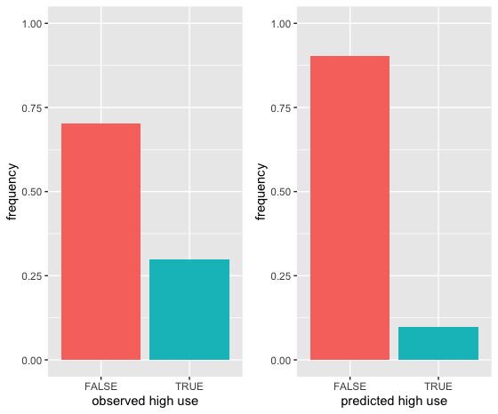

```r
high_u <- as.data.frame(prop.table(table(alc$high_use)))
predic <- as.data.frame(prop.table(table(alc$prediction)))
pp1 <- ggplot(high_u, aes(Var1, Freq)) + geom_col(aes(fill = Var1)) + scale_y_continuous(limits = 0:1) + ylab('frequency') + xlab('observed high use') + theme(legend.position = 'none')
pp2 <- ggplot(predic, aes(Var1, Freq)) + geom_col(aes(fill = Var1)) + scale_y_continuous(limits = 0:1) + ylab('frequency') + xlab('predicted high use') + theme(legend.position = 'none')
multiplot(pp1, pp2, cols = 2)
```

```r
mloss <- function(obs, prob) {
  res <- ifelse(prob > 0.5, 1, 0)
  mean(res != obs)
}
round(mloss(obs = alc$high_use, prob = alc$probability), 2)
```

```
[1] 0.27
```

The training error is 27%, the accuracy of this model is 73%.